# The Chase: An Analysis of Alex Ovechkin's Goal Scoring

By: Alex Chill

## Background

The National Hockey League ([NHL](https://www.nhl.com/)) is a professional ice hockey league, considered by many to be the highest level of hockey in the world. If you're unfamiliar with hockey or need a refresher, no worries! [This article](https://thehockeywriters.com/the-beginners-guide-to-becoming-an-nhl-fan/) is a good primer for how everything works, and [this article](https://bleacherreport.com/articles/941015-the-new-hockey-fans-guide-to-the-nhl) provides a fun take into some of the unofficial things that make hockey great. Hockey is my favorite sport to watch, so I hope you are just excited about it as I am!

As the current season continues, there are new storylines seemingly every day. Whether it be [COVID outbreaks on teams](https://www.cnbc.com/2021/12/18/nhls-bruins-and-predators-shut-down-through-the-holiday-due-to-covid-outbreaks.html), or [questions about participation in the Olympics](https://sports.yahoo.com/nhl-participation-in-beijing-olympics-highly-unlikely-after-covid-case-surge-151122170.html), there's always something going on. However, one storyline seems to stay longer than many: Alex Ovechkin's goal scoring.

For those that don't know of him, [Alex Ovechkin](https://en.wikipedia.org/wiki/Alexander_Ovechkin) (Ovi) is a Russian left winger for the Washington Capitals, and he's notorious for his goal scoring ability. He's not just a top goal scorer -- he's widely regarded as one of the best hockey players of all time. He currently has 752 NHL goals, [142 less](https://records.nhl.com/records/skater-records/goals/most-goals-career) than that of the highest goal scorer in NHL history, Wayne Gretzky. Seeing his goal scoring ability as it is, we can ask this question: will he catch Gretzky before the end of his career?

This analysis will aim to answer that question, using data analysis to attempt to predict Alex Ovechkin's goal scoring. Let's get started!

## Before We Start

Before we start, there are a few points to note:

- This analysis was used as my final project submission for CMSC320 at University of Maryland during the Fall 2021 semester. All numbers mentioned are as of December 20, 2021. If this code is run at a later date, the numbers will be different.
- I'd like to say a huge thank you to [MoneyPuck](https://moneypuck.com) for allowing the free use of their data. All of the data I use during the analysis [comes from them](https://moneypuck.com/data.htm), so thank you so so much again!
- The code boxes all contain comments with more detail for what important lines are doing.
- All of the code here was written in Python. There are some additional external libraries I've made use of during development, including:
  1. [pandas](https://pandas.pydata.org/)
  2. [NumPy](https://numpy.org/)
  3. [Requests](https://docs.python-requests.org/en/latest/)
  4. [Matplotlib](https://matplotlib.org/)
  5. [statsmodels](https://www.statsmodels.org/stable/index.html)
  6. [scikit-learn](https://scikit-learn.org/stable/)

  Before following along, see the links above to install and get familiar with the packages.

## The Analysis

Now that we've got our packages installed, it's time to start the analysis! When thinking about predicting Ovi's goal scoring, the first thing I thought of was to look at his offensive efficiency. Namely, for this analysis, I kept it simple: I define offensive efficiency as goals per shot attempt.

### Offensive Efficiency

The first step in any data analysis problem is getting the data. We can see below the code statement that gets Game-by-Game data for Ovi, which we'll use to get shot attempt and goal results to compute offensive efficiency.

```python
import requests
import pandas as pd
from io import BytesIO

# send HTTP GET request for Alex Ovechkin game-by-game stats
game_req = requests.get("https://moneypuck.com/moneypuck/playerData/careers/gameByGame/regular/skaters/8471214.csv")

# read in the CSV using the Bytes returned from the GET request
ovi_game_data = pd.read_csv(BytesIO(game_req.content))

display(ovi_game_data)
```

|  | playerId | season | name | gameId | playerTeam | opposingTeam | home_or_away | gameDate | position | situation | ... | OffIce_F_xGoals | OffIce_A_xGoals | OffIce_F_shotAttempts | OffIce_A_shotAttempts | xGoalsForAfterShifts | xGoalsAgainstAfterShifts | corsiForAfterShifts | corsiAgainstAfterShifts | fenwickForAfterShifts | fenwickAgainstAfterShifts |
| --- | --- | --- | --- | --- | --- | --- | --- | --- | --- | --- | --- | --- | --- | --- | --- | --- | --- | --- | --- | --- | --- |
| 0 | 8471214 | 2008 | Alex Ovechkin | 2008020013 | WSH | ATL | AWAY | 20081010 | L | other | ... | 0.094 | 0.000 | 2.0 | 1.0 | 0.000 | 0.000 | 0.0 | 0.0 | 0.0 | 0.0 |
| 1 | 8471214 | 2008 | Alex Ovechkin | 2008020013 | WSH | ATL | AWAY | 20081010 | L | all | ... | 1.737 | 1.590 | 30.0 | 29.0 | 0.000 | 0.000 | 0.0 | 0.0 | 0.0 | 0.0 |
| 2 | 8471214 | 2008 | Alex Ovechkin | 2008020013 | WSH | ATL | AWAY | 20081010 | L | 5on5 | ... | 1.069 | 1.157 | 24.0 | 18.0 | 0.071 | 0.000 | 1.0 | 1.0 | 1.0 | 0.0 |
| 3 | 8471214 | 2008 | Alex Ovechkin | 2008020013 | WSH | ATL | AWAY | 20081010 | L | 4on5 | ... | 0.574 | 0.434 | 4.0 | 10.0 | 0.000 | 0.000 | 0.0 | 0.0 | 0.0 | 0.0 |
| 4 | 8471214 | 2008 | Alex Ovechkin | 2008020013 | WSH | ATL | AWAY | 20081010 | L | 5on4 | ... | 0.000 | 0.000 | 0.0 | 0.0 | 0.000 | 0.000 | 0.0 | 0.0 | 0.0 | 0.0 |
| ... | ... | ... | ... | ... | ... | ... | ... | ... | ... | ... | ... | ... | ... | ... | ... | ... | ... | ... | ... | ... | ... |
| 4905 | 8471214 | 2021 | Alex Ovechkin | 2021020484 | WSH | LAK | HOME | 20211219 | L | other | ... | 0.000 | 0.257 | 0.0 | 2.0 | 0.000 | 0.000 | 0.0 | 0.0 | 0.0 | 0.0 |
| 4906 | 8471214 | 2021 | Alex Ovechkin | 2021020484 | WSH | LAK | HOME | 20211219 | L | all | ... | 1.077 | 0.587 | 31.0 | 33.0 | 0.000 | 0.000 | 0.0 | 0.0 | 0.0 | 0.0 |
| 4907 | 8471214 | 2021 | Alex Ovechkin | 2021020484 | WSH | LAK | HOME | 20211219 | L | 5on5 | ... | 0.904 | 0.278 | 27.0 | 21.0 | 0.011 | 0.022 | 2.0 | 1.0 | 1.0 | 1.0 |
| 4908 | 8471214 | 2021 | Alex Ovechkin | 2021020484 | WSH | LAK | HOME | 20211219 | L | 4on5 | ... | 0.000 | 0.000 | 0.0 | 0.0 | 0.000 | 0.000 | 0.0 | 0.0 | 0.0 | 0.0 |
| 4909 | 8471214 | 2021 | Alex Ovechkin | 2021020484 | WSH | LAK | HOME | 20211219 | L | 5on4 | ... | 0.142 | 0.000 | 3.0 | 1.0 | 0.000 | 0.000 | 0.0 | 0.0 | 0.0 | 0.0 |

4910 rows × 157 columns

As seen above, we now have our data for different situations for all of Ovi's games since the 2008 season. The next step is to clean the data. Since the data from Moneypuck is tidy already, there was not much to do for cleaning here. As such, we can continue to the next step: the metric computation and analysis. As mentioned before, we define offensive efficiency as goals per shot attempt. For this analysis, I decided that going year-by-year would provide the easiest interpretation, so we iterate every year from 2008 to 2021, getting all goals and shot attempts from that year. See below for a plot of our metric:

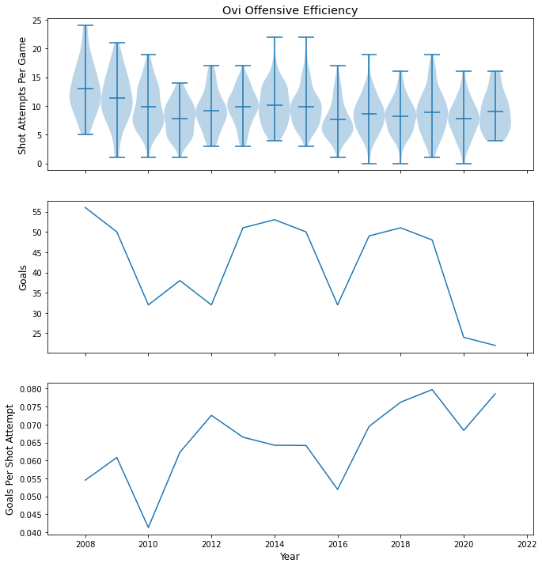

```python
import numpy as np
import matplotlib.pyplot as plt

# gets all seasons seen in the data (should be 2008-2021 for this)
unique_yrs = np.unique(ovi_game_data["season"])

# holds n arrays, each containing the number of shot attempts per game for that year (n = len(unique_yrs))
shots_by_yr = []

# same but for goals
goals_by_yr = []

# same but for goals per shot attempt
gpsa_by_yr = []

# go through the years and populate the above arrays
for yr in unique_yrs:
    # note the choice of metrics -- we could have refined this by choosing 5 on 5, 5 on 4, etc. instead of all
    # similarly, we could have chosen other metrics instead of I_F_shotAttempts
    curr_yr = ovi_game_data[(ovi_game_data["season"] == yr) & (ovi_game_data["situation"] == "all")]
    shots_by_yr.append(curr_yr["I_F_shotAttempts"])
    to_append = (curr_yr["I_F_goals"].sum() / curr_yr["I_F_shotAttempts"].sum())
    goals_by_yr.append(curr_yr["I_F_goals"].sum())
    gpsa_by_yr.append(to_append)

# plot the data
figure, axis = plt.subplots(nrows = 3, sharex = True, figsize = (11, 12))

axis[0].violinplot(shots_by_yr, unique_yrs, widths = 1, showmeans = True)
axis[0].set_ylabel("Shot Attempts Per Game", fontsize = "large")
axis[0].set_title("Ovi Offensive Efficiency", fontsize = "x-large")

axis[1].plot(unique_yrs, goals_by_yr)
axis[1].set_ylabel("Goals", fontsize = "large")

axis[2].plot(unique_yrs, gpsa_by_yr)
axis[2].set_ylabel("Goals Per Shot Attempt", fontsize = "large")

plt.xlabel("Year", fontsize = "large")
plt.show()
```

The plot above shows shot attempts per year, goals per year, and goals per shot attempt (gpsa) for every year. As we can see, his gpsa fluctuates quite a bit year to year, but there may be a general trend. If we see a strong trend, this may be a good metric to use for predicting how many goals he'll score.

To find out a relationship between two variables, we can use Linear Regression. If you're unfamiliar, [this](http://www.stat.yale.edu/Courses/1997-98/101/linreg.htm) is a good starter resource. Specifically, we use `statsmodels`' [Ordinary Least Squares](https://en.wikipedia.org/wiki/Ordinary_least_squares) to compute a Regression, using the formula input style (docs [found here](https://www.statsmodels.org/dev/example_formulas.html)).

```python
import statsmodels.formula.api as sm

# make a dataframe with the year and goals per shot attempt for inputting into statsmodels
gpsa_df = pd.DataFrame(columns = ["year", "gpsa"])

# independent variable
gpsa_df["year"] = unique_yrs

# dependent variable
gpsa_df["gpsa"] = gpsa_by_yr

# make an Ordinary Least Squares regression model for the data
gpsa_model = sm.ols(formula = "gpsa ~ year", data = gpsa_df).fit()
gpsa_model.summary()
```

OLS Regression Results

| Dep. Variable: | gpsa | R-squared: | 0.450 |
| --- | --- | --- | --- |
| Model: | OLS | Adj. R-squared: | 0.404 |
| Method: | Least Squares | F-statistic: | 9.824 |
| Date: | Mon, 20 Dec 2021 | Prob (F-statistic): | 0.00862 |
| Time: | 19:39:50 | Log-Likelihood: | 48.385 |
| No. Observations: | 14 | AIC: | -92.77 |
| Df Residuals: | 12 | BIC: | -91.49 |
| Df Model: | 1 |  |  |
| Covariance Type: | nonrobust |  |  |

|  | coef | std err | t | P>\|t\| | [0.025 | 0.975] |
| --- | --- | --- | --- | --- | --- | --- |
| Intercept | -3.3870 | 1.101 | -3.075 | 0.010 | -5.787 | -0.987 |
| year | 0.0017 | 0.001 | 3.134 | 0.009 | 0.001 | 0.003 |

| Omnibus: | 3.909 | Durbin-Watson: | 2.095 |
| --- | --- | --- | --- |
| Prob(Omnibus): | 0.142 | Jarque-Bera (JB): | 2.057 |
| Skew: | -0.935 | Prob(JB): | 0.357 |
| Kurtosis: | 3.174 | Cond. No. | 1.01e+06 |

Notes:  
[1] Standard Errors assume that the covariance matrix of the errors is correctly specified.  
[2] The condition number is large, 1.01e+06. This might indicate that there are  
strong multicollinearity or other numerical problems.

There is a lot of info here, but there are a couple of important places to look. In the middle section, in the "year" row, the `P > |t|` column contains a value of 0.009. This is a good value, meaning that there is likely a relationship between the gpsa and year. However, looking at the very top right, we see the R-squared value is 0.450. This is not very good. Before we continue, we can visualize the Regression to help see the relationship:

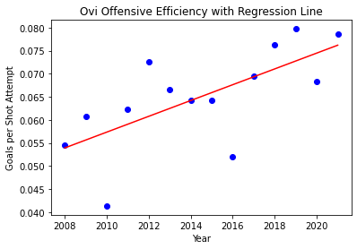

```python
from sklearn import linear_model

# make a regression model, use it to make a plot
gpsa_model_g = linear_model.LinearRegression().fit(gpsa_df[["year"]], gpsa_df["gpsa"])

plt.scatter(unique_yrs, gpsa_by_yr, c = "blue")
plt.plot(unique_yrs, gpsa_model_g.predict(gpsa_df[["year"]]), c = "red")

plt.xlabel("Year")
plt.ylabel("Goals per Shot Attempt")
plt.title("Ovi Offensive Efficiency with Regression Line")

plt.show()
```

As we can see, there is a positive trend, but the Regression isn't that strong. This means that there could be a correlation between the two variables, but if years increase that doesn't necessarily mean an increase in offensive efficiency will occur. This isn't ideal -- we want a more robust model for predicting future goals. From here, I thought of what I knew about Ovi. One of the more famous things about his game is [the Ovi spot](https://www.washingtontimes.com/news/2019/mar/6/alex-ovechkin-how-capitals-star-gets-work-done-his/), where he is known for being particularly lethal at scoring. That got me to thinking: could the spot he shoots from have any indication on how many goals he'll score? That's what we'll explore next.

As an aside -- [here's a video](https://www.youtube.com/watch?v=oXTa9qsr2wg) of Ovi shooting from the "spot." You can see just how lethal he is from there.

## Shot Location

Now, for the analysis. Since we only have game data from our Offensive Efficiency analysis, we need shot data. MoneyPuck has this, as well, with all NHL shots going back to the 2007 season. There are a few things to note here. The 2007-2020 dataset is huge, so downloading may take some time and space may be of concern. I included a couple of lines of code to automatically remove the full data (the `.csv` files) after getting what we need from them. However, if you want to extend this analysis, feel free to remove those lines. Another thing -- the shot data is sent back in a `ZIP` file. As such, we use the [zipfile](https://docs.python.org/3/library/zipfile.html#zipfile.ZipFile.namelist) package from the Python Standard Library.

Note -- if you have trouble getting the 2007-2020 data the automatic way, you can manually download it from [here](https://peter-tanner.com/moneypuck/downloads/shots_2007-2020.zip). Just make sure to extract the ZIP and put it in the directory where your Python script (or IPython Notebook) is.

With these things out of the way, we can continue on to the data import:

```python
import zipfile as zf
import os

# request, same as above
prev_req = requests.get("https://peter-tanner.com/moneypuck/downloads/shots_2007-2020.zip")
curr_req = requests.get("https://peter-tanner.com/moneypuck/downloads/shots_2021.zip")

# since we have zips this time, we use ZipFile to handle them
prev_zip = zf.ZipFile(BytesIO(prev_req.content))
curr_zip = zf.ZipFile(BytesIO(curr_req.content))

p_fname = prev_zip.namelist()[0]
c_fname = curr_zip.namelist()[0]

# only one file in each zip, so this extracts to the current directory
prev_zip.extract(p_fname)
curr_zip.extract(c_fname)

# read in the data
prev_shot_data = pd.read_csv(p_fname)
curr_shot_data = pd.read_csv(c_fname)

# comment these lines out if you want to keep the full shot datasets (not just Ovi's shots)
os.remove(p_fname)
os.remove(c_fname)

# gets shots just from Ovi
ovi_prev = prev_shot_data[prev_shot_data["shooterName"] == "Alex Ovechkin"]
ovi_curr = curr_shot_data[curr_shot_data["shooterName"] == "Alex Ovechkin"]

# save for future use
ovi_prev.to_csv("ovi_07-20.csv")
ovi_curr.to_csv("ovi_21.csv")
```

Now that we have the data imported, we saw that it took a bit of time. The last two lines in the above code box save the Ovi shot data in `.csv` files for later, which will reduce the need for downloading time. If running this code multiple times, you only need to run the above box once, and the below box will do all you need.

There are a few data tidying tasks to do. With each shot entry comes many metrics, but two notable ones we'll use are Arena X and Y coordinates. [This website](http://blog.war-on-ice.com/) (find the section about Location data) describes the need for adjustments in the X and Y coordinates, so these are the locations we'll use. Since the data is given with shots on different sides of the ice, visualizing common shot locations may be difficult. As such, we include a couple lines of code to add a new column indicating the Y position if we assume shots were only taken on one side. See below for the code and dataset:

```python
# run this if you've already run above and you're coming back
ovi_curr = pd.read_csv("ovi_21.csv")
ovi_prev = pd.read_csv("ovi_07-20.csv")

# combines the two datasets and moves all shots to one side for future use
ovi_all = ovi_prev.append(ovi_curr)
ovi_all["oneSideY"] = ovi_all["arenaAdjustedYCord"]

other_side = ovi_all.loc[ovi_all["arenaAdjustedXCord"] > 0, "arenaAdjustedYCord"] * -1
ovi_all.loc[ovi_all["arenaAdjustedXCord"] > 0, "oneSideY"] = other_side

display(ovi_all)
```

|  | Unnamed: 0 | shotID | homeTeamCode | awayTeamCode | season | isPlayoffGame | game_id | homeTeamWon | id | time | ... | xRebound | xPlayContinuedInZone | xPlayContinuedOutsideZone | xPlayStopped | xShotWasOnGoal | isHomeTeam | shotWasOnGoal | teamCode | arenaAdjustedXCordABS | oneSideY |
| --- | --- | --- | --- | --- | --- | --- | --- | --- | --- | --- | --- | --- | --- | --- | --- | --- | --- | --- | --- | --- | --- |
| 0 | 399 | 399 | BUF | WSH | 2020 | 0 | 20006 | 0 | 9 | 15 | ... | 0.037226 | 0.458854 | 0.287405 | 0.021302 | 0.655817 | 0.0 | 1.0 | WSH | 48.0 | -28.0 |
| 1 | 409 | 409 | BUF | WSH | 2020 | 0 | 20006 | 0 | 50 | 630 | ... | 0.053707 | 0.483461 | 0.269780 | 0.018304 | 0.715028 | 0.0 | 1.0 | WSH | 54.0 | -23.0 |
| 2 | 433 | 433 | BUF | WSH | 2020 | 0 | 20006 | 0 | 147 | 1904 | ... | 0.046343 | 0.495554 | 0.264116 | 0.025089 | 0.730061 | 0.0 | 0.0 | WSH | 56.0 | -30.0 |
| 3 | 461 | 461 | BUF | WSH | 2020 | 0 | 20006 | 0 | 239 | 3150 | ... | 0.036231 | 0.369436 | 0.262905 | 0.027268 | 0.692000 | 0.0 | 0.0 | WSH | 37.0 | 30.0 |
| 4 | 462 | 462 | BUF | WSH | 2020 | 0 | 20006 | 0 | 246 | 3287 | ... | 0.038559 | 0.395004 | 0.334022 | 0.025887 | 0.696847 | 0.0 | 1.0 | WSH | 37.0 | 30.0 |
| ... | ... | ... | ... | ... | ... | ... | ... | ... | ... | ... | ... | ... | ... | ... | ... | ... | ... | ... | ... | ... | ... |
| 205 | 40158 | 283 | WSH | LAK | 2021 | 0 | 20484 | 0 | 131 | 1278 | ... | 0.014284 | 0.338295 | 0.503678 | 0.015153 | 0.783274 | 1.0 | 1.0 | WSH | 26.0 | 15.0 |
| 206 | 40160 | 285 | WSH | LAK | 2021 | 0 | 20484 | 0 | 142 | 1305 | ... | 0.051010 | 0.440165 | 0.240133 | 0.026273 | 0.754822 | 1.0 | 0.0 | WSH | 56.0 | -29.0 |
| 207 | 40162 | 287 | WSH | LAK | 2021 | 0 | 20484 | 0 | 149 | 1378 | ... | 0.049638 | 0.429739 | 0.255741 | 0.023268 | 0.757323 | 1.0 | 1.0 | WSH | 55.0 | -28.0 |
| 208 | 40165 | 290 | WSH | LAK | 2021 | 0 | 20484 | 0 | 157 | 1519 | ... | 0.056188 | 0.483800 | 0.209239 | 0.018771 | 0.703535 | 1.0 | 1.0 | WSH | 56.0 | -25.0 |
| 209 | 40176 | 301 | WSH | LAK | 2021 | 0 | 20484 | 0 | 222 | 2201 | ... | 0.033543 | 0.444732 | 0.308255 | 0.019596 | 0.736848 | 1.0 | 1.0 | WSH | 71.0 | 33.0 |

8250 rows × 126 columns

Now that we have the data, let's do some analysis! The first thing we can do is visualize what we have. Below, we create a function that plots the shots on a top-down view of the rink, with red dots indicating shot attempts that missed, blue dots indicating shots attempts that were goals, and green squares indicating the nets.

One thing to note: we exclude empty net shots and goals for this analysis. Empty net goals are much less common, and generally only occur when the Capitals are winning, which we won't be predicting here. As such, it's much simpler to exclude the empty net goals.

```python
# given the dataset, the year range, and whether the map desired is a heatmap
# note this function isn't required, but it reduces code duplication
def plot_shots(data, title, isHeatmap):
    # gets only the columns we'll use -- note the inclusion of only non-empty net shots
    ovi_shot_coords = data[["goal", "shotOnEmptyNet", "arenaAdjustedXCord", "arenaAdjustedYCord", "oneSideY",\
                           "arenaAdjustedXCordABS", "xGoal"]]
    ovi_shot_coords = ovi_shot_coords[ovi_shot_coords["shotOnEmptyNet"] != 1]

    makes = ovi_shot_coords[ovi_shot_coords["goal"] == 1]
    misses = ovi_shot_coords[ovi_shot_coords["goal"] == 0]

    # differs the plots based on whether we want a heatmap -- changes the colors of the plot
    if not isHeatmap:
        # scatters the x and y points of the makes and misses -- in blue and red, respectively
        plt.scatter(misses["arenaAdjustedXCord"], misses["arenaAdjustedYCord"], c = "red")
        plt.scatter(makes["arenaAdjustedXCord"], makes["arenaAdjustedYCord"], c = "blue")
    else:
        plt.scatter(misses["arenaAdjustedXCord"], misses["arenaAdjustedYCord"], c = misses["xGoal"], cmap = "Reds")
        plt.scatter(makes["arenaAdjustedXCord"], makes["arenaAdjustedYCord"], c = makes["xGoal"], cmap = "Blues")

    # plots "nets" as a green square
    plt.scatter([-90, 90], [0,0], c = "green", marker = "s", s = 250)

    plt.xticks([])
    plt.yticks([])

    plt.title("Alex Ovechkin Shots in " + title + " w/ Non-Empty Net Goals")

    # create a new figure for the new angle
    plt.figure()

    # similar to above
    if not isHeatmap:
        # we change the viewing angle for this plot, to make the side he shoots from more apparent
        plt.scatter(misses["oneSideY"], misses["arenaAdjustedXCordABS"], c = "red")
        plt.scatter(makes["oneSideY"], makes["arenaAdjustedXCordABS"], c = "blue")
    else:
        plt.scatter(misses["oneSideY"], misses["arenaAdjustedXCordABS"], c = misses["xGoal"], cmap = "Reds")
        plt.scatter(makes["oneSideY"], makes["arenaAdjustedXCordABS"], c = makes["xGoal"], cmap = "Blues")

    # green square as net again
    plt.scatter(0, 90, c = "green", marker = "s", s = 250)

    plt.xticks([])
    plt.yticks([])

    plt.show()
```

First, we can look at the current season:

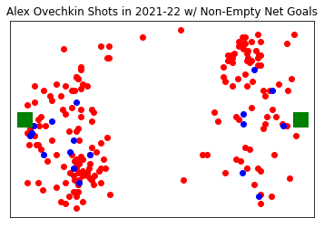

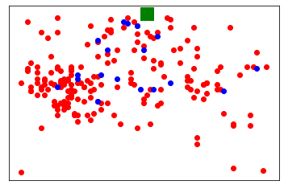

```python
plot_shots(ovi_all[ovi_all["season"] == 2021], "2021-22", False)
```

Next, we can look at 2007 to 2020, and after we can provide some analysis.

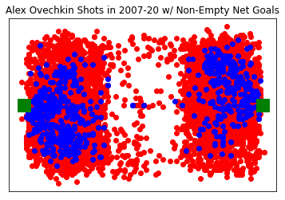

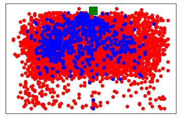

```python
plot_shots(ovi_all[ovi_all["season"] != 2021], "2007-20", False)
```

As we can see, this season, most all of his shot have come from left of the net (right of the goaltender), near the circle (the Ovi spot :) ). Over his career since 2007, mots of his goals have come from close to the net and the Ovi spot. With this in mind, we know that there is a potential relationship between location of shot and whether he'll score.

Another visualization we can make is heatmaps of his shots. For each shot, we can define the color based on the probability of the shot being a goal. See below for the 2021 and 2007-2020 graphs:

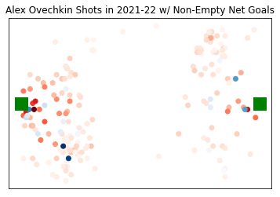

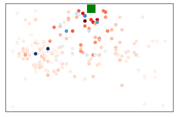

```python
plot_shots(ovi_all[ovi_all["season"] == 2021], "2021-22", True)
```

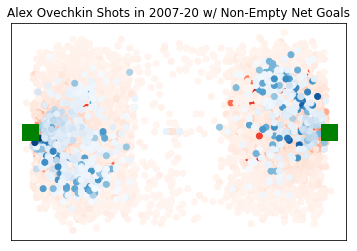

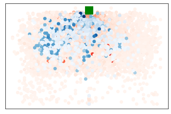

```python
plot_shots(ovi_all[ovi_all["season"] != 2021], "2007-20", True)
```

Here, we see that Ovi doesn't miss miss many high probability chances from his spots, and makes many low probability goals from his spots. This further supports the notion that location may affect goal scoring.

## Predicting Future Scoring

Now that we've got the visualization done, let's do some prediction. The ultimate goal here is to predict how many goals Ovi will get in the rest of his career. There are a few tasks to do in this regard, which we'll start with below.

### The Model

To predict goal scoring, we can separate based on a few parameters. The way we'll go about this here is via a classification model. Given some parameters, define whether the result is a goal. Of course, we need the X and Y coordinates of the shot. However, there may be some teams that Ovi shoots better against. Thus, we can include the X, Y, and Team as features (inputs) to the model, and the label (output) will be whether the shot is a goal or not. For more info about features and labels (and other ML stuff), [see here](https://developers.google.com/machine-learning/crash-course/framing/ml-terminology).

### Data Tidying and Model Preparation

In the shot data, there are some duplicate teams (the LAK and L.A, etc.). Additionally, the [Atlanta Thrashers became the Winnipeg Jets in 2011](https://en.wikipedia.org/wiki/Winnipeg_Jets). As a result, we modify the shot data to include these changes. Additionally, we find all of the teams that Ovi has shot against (since he's only ever played for Washington that makes our life much easier). This is because the shot data doesn't have a dedicated "opponent team" column, so we make our own:

```python
# clean the shot data up a bit by merging duplicate teams, combining ATL and WPG (ATL moved WPG)
ovi_all.loc[ovi_all["homeTeamCode"] == "ATL", "homeTeamCode"] = "WPG"
ovi_all.loc[ovi_all["awayTeamCode"] == "ATL", "awayTeamCode"] = "WPG"

ovi_all.loc[ovi_all["homeTeamCode"] == "LAK", "homeTeamCode"] = "L.A"
ovi_all.loc[ovi_all["awayTeamCode"] == "LAK", "awayTeamCode"] = "L.A"

ovi_all.loc[ovi_all["homeTeamCode"] == "NJD", "homeTeamCode"] = "N.J"
ovi_all.loc[ovi_all["awayTeamCode"] == "NJD", "awayTeamCode"] = "N.J"

ovi_all.loc[ovi_all["homeTeamCode"] == "SJS", "homeTeamCode"] = "S.J"
ovi_all.loc[ovi_all["awayTeamCode"] == "SJS", "awayTeamCode"] = "S.J"

ovi_all.loc[ovi_all["homeTeamCode"] == "TBL", "homeTeamCode"] = "T.B"
ovi_all.loc[ovi_all["awayTeamCode"] == "TBL", "awayTeamCode"] = "T.B"

# gets the different home and away teams, uses set union to combine them (since there are some teams
# that Washington hasn't played at home yet)
unique_home = np.unique(ovi_all["homeTeamCode"])
unique_away = np.unique(ovi_all["awayTeamCode"])
unique_teams = np.union1d(unique_home, unique_away)
```

Before we can get modeling, we can do one more thing to make our life a bit easier. For each of the different teams, we can assign its position in the `unique_teams` list above. This will allow it to be imported into the model, as well as help us a bit down the line. The below function takes in a list and a team, and finds the team within that list. We can guarantee the team will be in the list so there's no worry about elements not being there.

```python
# maps the passed team to its index in the passed array
def team_map(teams, team):
    return np.argwhere(teams == team)[0][0]
```

Now, we can go through each shot, getting the team that Ovi shot against:

```python
# array containing the team faced for each shot
team_faced = []
for row in ovi_all.iterrows():
    # if the home team is Washington, use the away team, and the home team otherwise
    if row[1]["homeTeamCode"] == "WSH":
        team_faced.append(team_map(unique_teams, row[1]["awayTeamCode"]))
    else:
        team_faced.append(team_map(unique_teams, row[1]["homeTeamCode"]))

# add the array to the dataset
ovi_all["oppTeamCode"] = team_faced
```

### Implementing The Model

Now that our inputs are tidied, we can proceed with modeling. For this, we use a [Gaussian Process Classifier](https://scikit-learn.org/stable/modules/generated/sklearn.gaussian_process.GaussianProcessClassifier.html). For more informaton about types of classifiers to use, [look here](https://scikit-learn.org/stable/auto_examples/classification/plot_classifier_comparison.html).

To implement the model, we first split the data as part of cross validation using [`train_test_split`](https://scikit-learn.org/stable/modules/generated/sklearn.model_selection.train_test_split.html). Then, we create our GPC, with random state for consistent output (if you run it at home with the same data as me you'll get the same output as me). Then, we can fit the model with the training data. See the outputted score:

```python
from sklearn.gaussian_process import GaussianProcessClassifier as GPC
from sklearn.model_selection import train_test_split as tts

# we first split the data into training and testing sets
# the features (inputs) are the X,Y coordinates of the shot and the team he shoots against
# the label (output) is whether the shot was a goal
X_train, X_test, y_train, y_test = tts(ovi_all[["arenaAdjustedXCordABS", "oneSideY", "oppTeamCode"]],\
                                      ovi_all["goal"])

# use the GaussianProcessClassifier to create and fit our model
# note -- random_state was set to ensure consistency in every run, but this can be removed if not desired
model = GPC(copy_X_train = False, random_state = 8).fit(X_train, y_train)

# output the accuracy of the model using the test set
model.score(X_test, y_test)
```

```
0.8851187590887057
```

As seen above, the accuracy of our model on the test data is ~88.5%. This is good performance, meaning we can move on to the prediction!

### Predicting Future Scoring

To predict how many goals Ovi will score in the rest of his career, we need to estimate the number of shots he'll take in the rest of his career. For this, we can total the number shots he's ever attempted and divide it by the number of seasons he's played in. See below for this calculation:

```python
# calculate the mean shot attempts per year value
num_shotattempts = 0
for yr in unique_yrs:
    curr_yr = ovi_game_data[(ovi_game_data["season"] == yr) & (ovi_game_data["situation"] == "all")]

    # add the number of shot attempts seen in that year
    num_shotattempts += (curr_yr["I_F_shotAttempts"].sum())

# divide total shot attempts by number of years
avg_shotattempts = float(num_shotattempts) / float(len(unique_yrs))
avg_shotattempts
```

```
662.0
```

The outputted number above shows that, in an average year, he'll have 662 shot attempts. Note that this figure is a bit problematic because there have been multiple years in his career where he's played less games, meaning less shot attempts ([NHL Lockout in 2012](https://en.wikipedia.org/wiki/2012%E2%80%9313_NHL_lockout), COVID for the last two seasons). However, this is the metric we'll go with regardless, as it's the simplest to compute and understand.

### Basic Prediction

All of the predictions we'll make will be based on [randomness](https://en.wikipedia.org/wiki/Randomness). First, we'll look at near-pure randomness. We'll use the [`random`](https://docs.python.org/3/library/random.html) package in Python Standard to help with this.

One thing to note is the length of his career remaining. While it'd be great if he could play forever, he's currently 36 years old on the first year of a new 5 year contract. For the sake of this analysis, I'm going to assume he will retire at the end of [that contract](https://www.spotrac.com/nhl/washington-capitals/alex-ovechkin-2179/) (4.5-ish years seasons from now). Therefore, the number of shots he has left is 4.5 * 662, or 2979.

For our process, we'll run a number of "simulations," or just random runs of 2979 shots for some number of iterations. I chose 20, but you can feel free to choose more or less (the more you choose the longer the computations will take).

Now, we can see below for our simulations:

```python
import random as r

# seed the random number generator for consistent generation
r.seed(8)

# ~4.5 years left on his current contract, so take shot attempts per year * 4.5
shots_remaining = int(avg_shotattempts * 4.5)

# number of times we simulate seasons -- 20 is arbitrary, try changing this at home!
num_simulations = 20

# number of goals for each simulated run
sim_goals = []
for i in range(num_simulations):
    # number of goals seen for this run
    num_goals = 0

    # go through the calculated shots remaining value
    for i in range(shots_remaining):
        # generate random x, y, and team values over the possible range
        x = r.randrange(0, 90)
        y = r.randrange(-40, 40)
        team = r.randrange(0, 31)

        # if the model predicts a goal from this location, append 1 to the number of goals in this run
        if model.predict([[x, y, team]]) == 1:
            num_goals += 1
    sim_goals.append(num_goals)

print(sim_goals)
np.mean(sim_goals)
```

```
[130, 120, 123, 129, 103, 108, 107, 113, 131, 127, 105, 117, 116, 104, 105, 112, 142, 111, 94, 118]
```

```
115.75
```

Above, we can see the values of the simulations and the mean value. We know that Ovi is 142 goals behind Gretzky (as of December 20, 2021). Our simulations above indicate that, for the rest of his career, he will only score around 115 goals, so he won't make it to Gretzky.

There are some caveats here: this only includes regular season games, so if the Caps make the playoffs then there may be more scoring there.

The teams were chosen randomly, meaning that it's entirely possible that all shots could have been against 1 team, which is not the case in real life. This means that errors in team selecton are likely.

Finally, the locations above were *randomly chosen among the entire possible interval*. This means that the places he shoots from (and scores from) more were not taken into account. How can we fix this?

### Weighted Prediction

One idea to fix the problem is to weight certain areas over others. If he's more likely to shoot from the left side near the circle, we want to be more likely to select those X, Y values in our random number generation. First, we can identify where most of his goals are scored from. The below code indicates regions of X, Y values that show where Ovi is most likely to score from.

```python
# see the proportion of goals scored in this range of x values -- we see it's nearly 50
# so we can split 50-45-5
goals = ovi_all[ovi_all["goal"] == 1]
print(len(goals[(goals["arenaAdjustedXCordABS"] <= 65) & (goals["arenaAdjustedXCordABS"] > 35)]) \
      / len(goals["arenaAdjustedXCordABS"]))
print(len(goals[(goals["arenaAdjustedXCordABS"] > 65)]) \
      / len(goals["arenaAdjustedXCordABS"]))
print(len(goals[(goals["arenaAdjustedXCordABS"] <= 35) & (goals["arenaAdjustedXCordABS"] > 0)]) \
      / len(goals["arenaAdjustedXCordABS"]))
```

```
0.4979253112033195
0.4605809128630705
0.040110650069156296
```

As we can see, the percentages are about 50-45-5, so we'll translate those weights into the random number generation. See below for Y calculations:

```python
# similar for y, so we can split 45-45-10
print(len(goals[(goals["oneSideY"] <= 10) & (goals["oneSideY"] >= -10)]) / len(goals["oneSideY"]))
print(len(goals[(goals["oneSideY"] <= -10) & (goals["oneSideY"] >= -40)]) / len(goals["oneSideY"]))
print(len(goals[(goals["oneSideY"] >= 10)]) / len(goals["oneSideY"]))
```

```
0.45643153526970953
0.43983402489626555
0.12448132780082988
```

Similar story, but the weights are 45-45-10.

There is one more thing to tidy: the teams. We know that the team selection was inaccurate before, so we can select teams [similarly to how the NHL does it](https://en.wikipedia.org/wiki/Season_structure_of_the_NHL). As such, we can separate by divisional, non-divisional conference, and non-divisional non-conference opponents and use logic and [dictionaries](https://docs.python.org/3/tutorial/datastructures.html) to help implement the solution.

Now that the tidying is done, we can implement the weighted model. To determine how many games we've played against a certain team, we can create a new variable that contains shots remaining divided by the number of regular season games, meaning the number of shots per game. We can use that variable to define how many shots we've already seen against a given team, thereby limiting the amount of shots that team can see. This controls the team condition, and solves the problem for now.

To generate the X and Y values, we can generate a random number between 0 and 19 inclusive. We know that 50% of the time we'll see a value between 0 and 10 exclusive, so we can match that probability with the probability of being in the X coordinates of (35,65].

Following a similar process for the rest of the X and Y, we get a weighted generation for all 3 features, meaning the random number is more likely to be in the spots that he shoots from.

```python
# teams in the same division as Washington (Metropolitan Division)
div_teams = ["CAR", "CBJ", "N.J", "NYI", "NYR", "PHI", "PIT"]
div_teams = [team_map(unique_teams, i) for i in div_teams]

# teams in the same conference as Washington (Eastern Conference)
conf_teams = ["BOS", "BUF", "DET", "FLA", "MTL", "OTT", "T.B", "TOR"]
conf_teams = [team_map(unique_teams, i) for i in conf_teams]

# sat = shots_against_team, divide the number of games in a season so we know how many shots on average
# he'll take against each team
sat = int(shots_remaining / 82)

# similar to above, number of goals per simulation
sim_goals = []
for i in range(num_simulations):
    # to limit the number of games played against any one team, we have a map entry for each team
    teams_seen = {team_map(unique_teams, team) : 0 for team in unique_teams}

    # number of goals, go through each shot like last time
    num_goals = 0
    for i in range(shots_remaining):

        # generate a random integer between [0,19]
        x_val_rand = r.randrange(0,20)

        # this is the 50% we saw above
        if x_val_rand < 10:
            # the x value is in the range with ~50% of values
            x = r.randrange(35,66)

        # another range with 45%
        elif (x_val_rand >= 10) and (x_val_rand < 19):
            x = r.randrange(66, 90)
        else:
            x = r.randrange(0,35)

        # similar to x, but the ranges and %s are different
        y_val_rand = r.randrange(0,20)
        if y_val_rand < 9:
            y = r.randrange(-40, -9)
        elif (y_val_rand >= 9) and (y_val_rand < 18):
            y = r.randrange(-10, 11)
        else:
            y = r.randrange(10, 40)


        # we keep looking for a good team until we find one
        team_good = False
        while team_good == False:
            # generate a team
            team = r.randrange(0, 31)

            # get its value in the map
            c_team = teams_seen[team]

            # if it's a divisional opponent, WSH can play up to 4 times against them, so
            # we assume 4 games each with an average number of shots per game is the limit
            if team in div_teams and c_team < (4 * sat):
                team_good = True
                teams_seen[team] += 1
            # similar, but conference opponents have a limit of 3 games
            elif team in conf_teams and c_team < (3 * sat):
                team_good = True
                teams_seen[team] += 1
            # similar, but the non-conference, non-division opponents have a limit of 2 games
            elif ((team not in div_teams) and (team not in conf_teams)) and c_team < (2 * sat):
                team_good = True
                teams_seen[team] += 1

        # predict using the parameters, add 1 if a goal predicted
        if model.predict([[x, y, team]]) == 1:
            num_goals += 1

    sim_goals.append(num_goals)

print(sim_goals)
np.mean(sim_goals)
```

```
[135, 157, 161, 156, 146, 150, 156, 144, 155, 150, 152, 124, 181, 158, 169, 140, 162, 144, 157, 175]
```

```
153.6
```

## Results and Takeaways

As seen above, the expected number of goals is *much* higher (nearly 40 more!), with him being able to pass Gretzky just in regular season games over the next 4.5 seasons. This leads me to believe that shot location is imperative for Ovi. If he wants to catch Gretzky, he needs to shoot from his spots and shoot quite a bit. We already know he's dominant, but making him even more dominant from those spots would help his chances of catching Gretzky even more.

## Potential for Further Analysis

There are some limitations to this analysis, which we can discuss here. For the goal predictions, we assume no degradation in performance as time goes on. By this, I mean I assume no injuries and that he keeps the same level of performance for the rest of his career (we all know that the [Russian Machine Never Breaks](https://russianmachineneverbreaks.com/) :) ). Another limitation is that some of the assumptions made may be oversimplified, which could lead to oversimplified results. In the future, there may be the ability to include more metrics or less simple weights for shot locations, or the use of other features besides shot location.

## Final Remarks

Thank you so much again to MoneyPuck for allowing the use of their data.

And -- Thank you so much to you for reading! I hope you have found this analysis useful, and that you have a new found appreciation for hockey and Alex Ovechkin's chase to get to Gretzky!